# Untitled12 slides

## Effects of People Characteristics on Their Heart Disease

## Investigation Overview

##### In this investigation, I wanted to look at the characteristics of People that could have heart disease the main focus will be on the age of people and chest pain type ,the slope of the peak exercise ST segment and FastingBS

## Dataset Overview

> Cardiovascular diseases (CVDs) are the number 1 cause of death globally, taking an estimated 17.9 million lives each year, which accounts for 31% of all deaths worldwide. Four out of 5CVD deaths are due to heart attacks and strokes, and one-third of these deaths occur prematurely in people under 70 years of age. Heart failure is a common event caused by CVDs and this dataset contains 11 features that can be used to predict a possible heart disease.

## how many of these people in dataset have heart disease

> here we see that most of people in this data have heart diseas ( '1' ) and they about 500 people

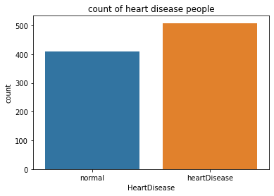

## Distribution of age

> the age data like a normal distribution data

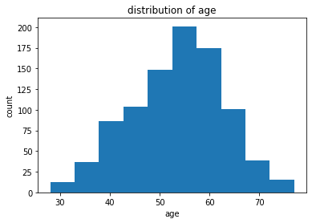

## Age vs HeartDisease

> We see that most people who have heart disease who are over 55

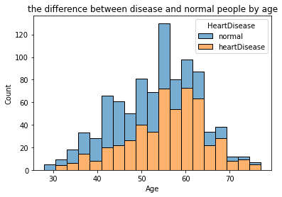

## Gender vs Heart Disease

> as wee see that male have heart disease than female

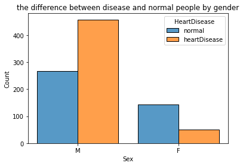

# chest pain type vs Heart disease

> the most chest pain type that make people have heart disease is ASY type

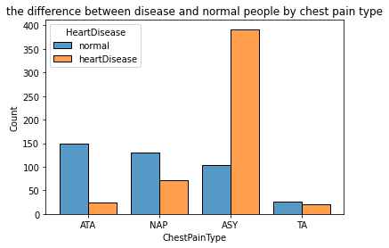

## RestingECG vs heart disease

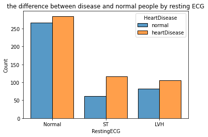

## ST_Slope vs Heart disease

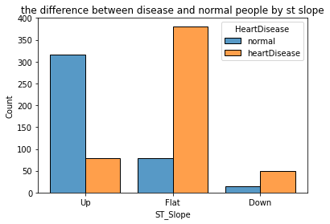

## FastingBS vs Heart Disease

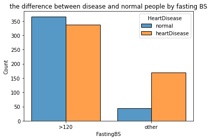

## Age and Heart Disease vs gender

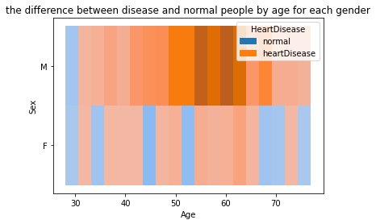

## Chest pain type and heart Disease vs gender

> here the male appear that thay have the most ASY type with having heart disease

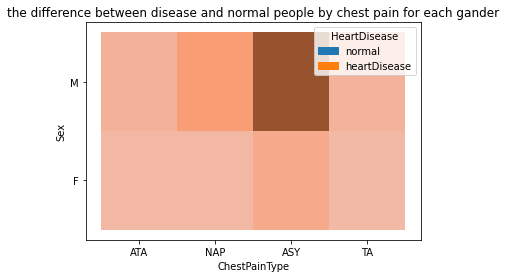

## RestingBP and heart disease vs age

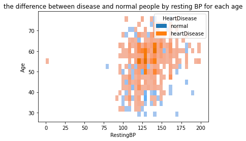